# Risk Factor Analysis

## Outcome Variable

**Outcome Variable:** dead6plus

## Predictor Variables

**Intervention Variable:** ever_sstunted024

**Adjustment Set:**

- sex
- arm
- brthmon
- vagbrth
- hhwealth_quart
- W_mage
- W_mhtcm
- W_mwtkg
- W_mbmi
- W_meducyrs
- W_feducyrs
- W_nrooms
- W_parity
- impsan
- safeh20
- delta_vagbrth
- delta_hhwealth_quart
- delta_W_mage
- delta_W_mhtcm
- delta_W_mwtkg
- delta_W_mbmi
- delta_W_meducyrs
- delta_W_feducyrs
- delta_W_nrooms
- delta_W_parity
- delta_impsan
- delta_safeh20

## Stratifying Variables

The analysis was stratified on these variable(s):

- studyid
- country

## Data Summary

| studyid | country | ever_sstunted024 | dead6plus | n_cell | n |
| --- | --- | --- | --- | --- | --- |
| Burkina Faso Zn | BURKINA FASO | 0 | 0 | 6262 | 7162 |
| Burkina Faso Zn | BURKINA FASO | 0 | 1 | 37 | 7162 |
| Burkina Faso Zn | BURKINA FASO | 1 | 0 | 852 | 7162 |
| Burkina Faso Zn | BURKINA FASO | 1 | 1 | 11 | 7162 |
| EE | PAKISTAN | 0 | 0 | 147 | 374 |
| EE | PAKISTAN | 0 | 1 | 0 | 374 |
| EE | PAKISTAN | 1 | 0 | 223 | 374 |
| EE | PAKISTAN | 1 | 1 | 4 | 374 |
| GMS-Nepal | NEPAL | 0 | 0 | 434 | 592 |
| GMS-Nepal | NEPAL | 0 | 1 | 1 | 592 |
| GMS-Nepal | NEPAL | 1 | 0 | 156 | 592 |
| GMS-Nepal | NEPAL | 1 | 1 | 1 | 592 |
| iLiNS-DOSE | MALAWI | 0 | 0 | 1433 | 1874 |
| iLiNS-DOSE | MALAWI | 0 | 1 | 102 | 1874 |
| iLiNS-DOSE | MALAWI | 1 | 0 | 314 | 1874 |
| iLiNS-DOSE | MALAWI | 1 | 1 | 25 | 1874 |
| iLiNS-DYAD-M | MALAWI | 0 | 0 | 948 | 1161 |
| iLiNS-DYAD-M | MALAWI | 0 | 1 | 21 | 1161 |
| iLiNS-DYAD-M | MALAWI | 1 | 0 | 185 | 1161 |
| iLiNS-DYAD-M | MALAWI | 1 | 1 | 7 | 1161 |
| JiVitA-3 | BANGLADESH | 0 | 0 | 17039 | 21039 |
| JiVitA-3 | BANGLADESH | 0 | 1 | 202 | 21039 |
| JiVitA-3 | BANGLADESH | 1 | 0 | 3689 | 21039 |
| JiVitA-3 | BANGLADESH | 1 | 1 | 109 | 21039 |
| JiVitA-4 | BANGLADESH | 0 | 0 | 4296 | 5432 |
| JiVitA-4 | BANGLADESH | 0 | 1 | 31 | 5432 |
| JiVitA-4 | BANGLADESH | 1 | 0 | 1086 | 5432 |
| JiVitA-4 | BANGLADESH | 1 | 1 | 19 | 5432 |
| Keneba | GAMBIA | 0 | 0 | 2101 | 2748 |
| Keneba | GAMBIA | 0 | 1 | 46 | 2748 |
| Keneba | GAMBIA | 1 | 0 | 568 | 2748 |
| Keneba | GAMBIA | 1 | 1 | 33 | 2748 |
| MAL-ED | BANGLADESH | 0 | 0 | 187 | 240 |
| MAL-ED | BANGLADESH | 0 | 1 | 0 | 240 |
| MAL-ED | BANGLADESH | 1 | 0 | 53 | 240 |
| MAL-ED | BANGLADESH | 1 | 1 | 0 | 240 |
| MAL-ED | INDIA | 0 | 0 | 177 | 235 |
| MAL-ED | INDIA | 0 | 1 | 0 | 235 |
| MAL-ED | INDIA | 1 | 0 | 58 | 235 |
| MAL-ED | INDIA | 1 | 1 | 0 | 235 |
| MAL-ED | PERU | 0 | 0 | 213 | 273 |
| MAL-ED | PERU | 0 | 1 | 1 | 273 |
| MAL-ED | PERU | 1 | 0 | 59 | 273 |
| MAL-ED | PERU | 1 | 1 | 0 | 273 |
| MAL-ED | SOUTH AFRICA | 0 | 0 | 191 | 261 |
| MAL-ED | SOUTH AFRICA | 0 | 1 | 0 | 261 |
| MAL-ED | SOUTH AFRICA | 1 | 0 | 70 | 261 |
| MAL-ED | SOUTH AFRICA | 1 | 1 | 0 | 261 |
| MAL-ED | TANZANIA, UNITED REPUBLIC OF | 0 | 0 | 112 | 245 |
| MAL-ED | TANZANIA, UNITED REPUBLIC OF | 0 | 1 | 0 | 245 |
| MAL-ED | TANZANIA, UNITED REPUBLIC OF | 1 | 0 | 133 | 245 |
| MAL-ED | TANZANIA, UNITED REPUBLIC OF | 1 | 1 | 0 | 245 |
| PROVIDE | BANGLADESH | 0 | 0 | 522 | 617 |
| PROVIDE | BANGLADESH | 0 | 1 | 2 | 617 |
| PROVIDE | BANGLADESH | 1 | 0 | 92 | 617 |
| PROVIDE | BANGLADESH | 1 | 1 | 1 | 617 |
| SAS-CompFeed | INDIA | 0 | 0 | 909 | 1389 |
| SAS-CompFeed | INDIA | 0 | 1 | 3 | 1389 |
| SAS-CompFeed | INDIA | 1 | 0 | 468 | 1389 |
| SAS-CompFeed | INDIA | 1 | 1 | 9 | 1389 |
| SAS-FoodSuppl | INDIA | 0 | 0 | 201 | 402 |
| SAS-FoodSuppl | INDIA | 0 | 1 | 0 | 402 |
| SAS-FoodSuppl | INDIA | 1 | 0 | 197 | 402 |
| SAS-FoodSuppl | INDIA | 1 | 1 | 4 | 402 |
| TanzaniaChild2 | TANZANIA, UNITED REPUBLIC OF | 0 | 0 | 1867 | 2096 |
| TanzaniaChild2 | TANZANIA, UNITED REPUBLIC OF | 0 | 1 | 0 | 2096 |
| TanzaniaChild2 | TANZANIA, UNITED REPUBLIC OF | 1 | 0 | 229 | 2096 |
| TanzaniaChild2 | TANZANIA, UNITED REPUBLIC OF | 1 | 1 | 0 | 2096 |
| VITAMIN-A | INDIA | 0 | 0 | 2682 | 3614 |
| VITAMIN-A | INDIA | 0 | 1 | 19 | 3614 |
| VITAMIN-A | INDIA | 1 | 0 | 901 | 3614 |
| VITAMIN-A | INDIA | 1 | 1 | 12 | 3614 |
| ZVITAMBO | ZIMBABWE | 0 | 0 | 9303 | 11708 |
| ZVITAMBO | ZIMBABWE | 0 | 1 | 251 | 11708 |
| ZVITAMBO | ZIMBABWE | 1 | 0 | 1989 | 11708 |
| ZVITAMBO | ZIMBABWE | 1 | 1 | 165 | 11708 |

The following strata were considered:

- studyid: Burkina Faso Zn, country: BURKINA FASO
- studyid: EE, country: PAKISTAN
- studyid: GMS-Nepal, country: NEPAL
- studyid: iLiNS-DOSE, country: MALAWI
- studyid: iLiNS-DYAD-M, country: MALAWI
- studyid: JiVitA-3, country: BANGLADESH
- studyid: JiVitA-4, country: BANGLADESH
- studyid: Keneba, country: GAMBIA
- studyid: MAL-ED, country: BANGLADESH
- studyid: MAL-ED, country: INDIA
- studyid: MAL-ED, country: PERU
- studyid: MAL-ED, country: SOUTH AFRICA
- studyid: MAL-ED, country: TANZANIA, UNITED REPUBLIC OF
- studyid: PROVIDE, country: BANGLADESH
- studyid: SAS-CompFeed, country: INDIA
- studyid: SAS-FoodSuppl, country: INDIA
- studyid: TanzaniaChild2, country: TANZANIA, UNITED REPUBLIC OF
- studyid: VITAMIN-A, country: INDIA
- studyid: ZVITAMBO, country: ZIMBABWE

### Dropped Strata

Some strata were dropped due to rare outcomes:

- studyid: EE, country: PAKISTAN
- studyid: GMS-Nepal, country: NEPAL
- studyid: MAL-ED, country: BANGLADESH
- studyid: MAL-ED, country: INDIA
- studyid: MAL-ED, country: PERU
- studyid: MAL-ED, country: SOUTH AFRICA
- studyid: MAL-ED, country: TANZANIA, UNITED REPUBLIC OF
- studyid: PROVIDE, country: BANGLADESH
- studyid: SAS-CompFeed, country: INDIA
- studyid: SAS-FoodSuppl, country: INDIA
- studyid: TanzaniaChild2, country: TANZANIA, UNITED REPUBLIC OF

## Methods Detail

We’re interested in the causal parameters $E[Y_a]$ for all values of $a \in \mathcal{A}$. These parameters represent the mean outcome if, possibly contrary to fact, we intervened to set all units to have $A=a$. Under the randomization and positivity assumptions, these are identified by the statistical parameters $\psi_a=E_W[E_{Y|A,W}(Y|A=a,W)]$. In addition, we’re interested in the mean of $Y$, $E[Y]$ under no intervention (the observed mean). We will estimate these parameters by using SuperLearner to fit the relevant likelihood factors – $E_{Y|A,W}(Y|A=a,W)$ and $p(A=a|W)$, and then updating our likelihood fit using a joint TMLE.

For unadjusted analyses ($W=\{\}$), initial likelihoods were estimated using Lrnr_glm to estimate the simple $E(Y|A)$ and Lrnr_mean to estimate $p(A)$. For adjusted analyses, a small library containing Lrnr_glmnet, Lrnr_xgboost, and Lrnr_mean was used.

Having estimated these parameters, we will then use the delta method to estimate relative risks and attributable risks relative to a prespecified baseline level of $A$.

# Results Detail

## Results Plots

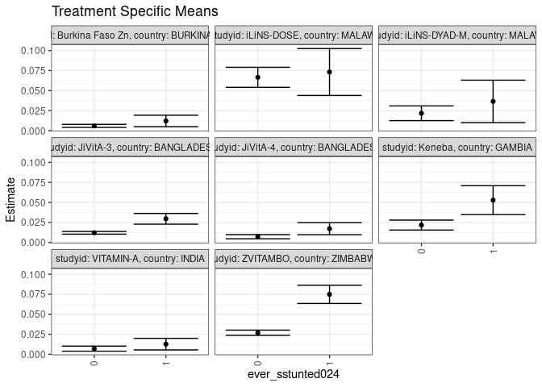

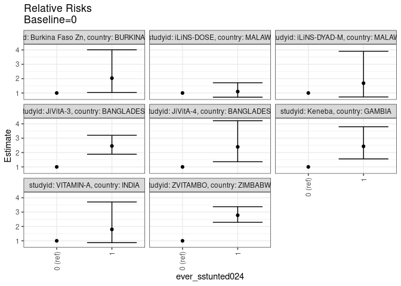

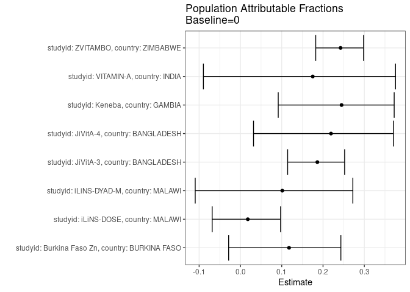

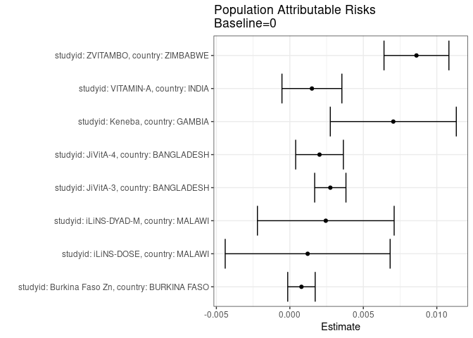

## Results Table

### Parameter: TSM

| studyid | country | intervention_level | baseline_level | estimate | ci_lower | ci_upper |
| --- | --- | --- | --- | --- | --- | --- |
| Burkina Faso Zn | BURKINA FASO | 0 | NA | 0.0059129 | 0.0040154 | 0.0078104 |
| Burkina Faso Zn | BURKINA FASO | 1 | NA | 0.0120298 | 0.0048362 | 0.0192233 |
| iLiNS-DOSE | MALAWI | 0 | NA | 0.0665572 | 0.0540447 | 0.0790697 |
| iLiNS-DOSE | MALAWI | 1 | NA | 0.0732071 | 0.0439094 | 0.1025049 |
| iLiNS-DYAD-M | MALAWI | 0 | NA | 0.0216718 | 0.0124998 | 0.0308438 |
| iLiNS-DYAD-M | MALAWI | 1 | NA | 0.0364583 | 0.0099356 | 0.0629811 |
| JiVitA-3 | BANGLADESH | 0 | NA | 0.0120287 | 0.0103487 | 0.0137087 |
| JiVitA-3 | BANGLADESH | 1 | NA | 0.0295558 | 0.0228610 | 0.0362506 |
| JiVitA-4 | BANGLADESH | 0 | NA | 0.0071860 | 0.0045842 | 0.0097878 |
| JiVitA-4 | BANGLADESH | 1 | NA | 0.0172103 | 0.0096976 | 0.0247230 |
| Keneba | GAMBIA | 0 | NA | 0.0217094 | 0.0154989 | 0.0279199 |
| Keneba | GAMBIA | 1 | NA | 0.0528186 | 0.0347852 | 0.0708521 |
| VITAMIN-A | INDIA | 0 | NA | 0.0070757 | 0.0039074 | 0.0102439 |
| VITAMIN-A | INDIA | 1 | NA | 0.0127147 | 0.0054833 | 0.0199460 |
| ZVITAMBO | ZIMBABWE | 0 | NA | 0.0269162 | 0.0236430 | 0.0301893 |
| ZVITAMBO | ZIMBABWE | 1 | NA | 0.0748586 | 0.0635228 | 0.0861944 |

### Parameter: E(Y)

| studyid | country | intervention_level | baseline_level | estimate | ci_lower | ci_upper |
| --- | --- | --- | --- | --- | --- | --- |
| Burkina Faso Zn | BURKINA FASO | NA | NA | 0.0067020 | 0.0048123 | 0.0085918 |
| iLiNS-DOSE | MALAWI | NA | NA | 0.0677695 | 0.0563864 | 0.0791525 |
| iLiNS-DYAD-M | MALAWI | NA | NA | 0.0241171 | 0.0152888 | 0.0329455 |
| JiVitA-3 | BANGLADESH | NA | NA | 0.0147821 | 0.0131375 | 0.0164266 |
| JiVitA-4 | BANGLADESH | NA | NA | 0.0092047 | 0.0066177 | 0.0117917 |
| Keneba | GAMBIA | NA | NA | 0.0287482 | 0.0224995 | 0.0349969 |
| VITAMIN-A | INDIA | NA | NA | 0.0085778 | 0.0055708 | 0.0115847 |
| ZVITAMBO | ZIMBABWE | NA | NA | 0.0355313 | 0.0321779 | 0.0388846 |

### Parameter: RR

| studyid | country | intervention_level | baseline_level | estimate | ci_lower | ci_upper |
| --- | --- | --- | --- | --- | --- | --- |
| Burkina Faso Zn | BURKINA FASO | 0 | 0 | 1.000000 | 1.0000000 | 1.000000 |
| Burkina Faso Zn | BURKINA FASO | 1 | 0 | 2.034493 | 1.0321762 | 4.010129 |
| iLiNS-DOSE | MALAWI | 0 | 0 | 1.000000 | 1.0000000 | 1.000000 |
| iLiNS-DOSE | MALAWI | 1 | 0 | 1.099913 | 0.7067748 | 1.711733 |
| iLiNS-DYAD-M | MALAWI | 0 | 0 | 1.000000 | 1.0000000 | 1.000000 |
| iLiNS-DYAD-M | MALAWI | 1 | 0 | 1.682292 | 0.7250786 | 3.903170 |
| JiVitA-3 | BANGLADESH | 0 | 0 | 1.000000 | 1.0000000 | 1.000000 |
| JiVitA-3 | BANGLADESH | 1 | 0 | 2.457105 | 1.8850492 | 3.202762 |
| JiVitA-4 | BANGLADESH | 0 | 0 | 1.000000 | 1.0000000 | 1.000000 |
| JiVitA-4 | BANGLADESH | 1 | 0 | 2.394977 | 1.3599337 | 4.217790 |
| Keneba | GAMBIA | 0 | 0 | 1.000000 | 1.0000000 | 1.000000 |
| Keneba | GAMBIA | 1 | 0 | 2.432987 | 1.5582603 | 3.798740 |
| VITAMIN-A | INDIA | 0 | 0 | 1.000000 | 1.0000000 | 1.000000 |
| VITAMIN-A | INDIA | 1 | 0 | 1.796953 | 0.8714356 | 3.705425 |
| ZVITAMBO | ZIMBABWE | 0 | 0 | 1.000000 | 1.0000000 | 1.000000 |
| ZVITAMBO | ZIMBABWE | 1 | 0 | 2.781173 | 2.2903446 | 3.377187 |

### Parameter: PAR

| studyid | country | intervention_level | baseline_level | estimate | ci_lower | ci_upper |
| --- | --- | --- | --- | --- | --- | --- |
| Burkina Faso Zn | BURKINA FASO | 0 | NA | 0.0007891 | -0.0001449 | 0.0017232 |
| iLiNS-DOSE | MALAWI | 0 | NA | 0.0012123 | -0.0043992 | 0.0068237 |
| iLiNS-DYAD-M | MALAWI | 0 | NA | 0.0024453 | -0.0022065 | 0.0070971 |
| JiVitA-3 | BANGLADESH | 0 | NA | 0.0027534 | 0.0016888 | 0.0038179 |
| JiVitA-4 | BANGLADESH | 0 | NA | 0.0020187 | 0.0003956 | 0.0036418 |
| Keneba | GAMBIA | 0 | NA | 0.0070388 | 0.0027516 | 0.0113260 |
| VITAMIN-A | INDIA | 0 | NA | 0.0015021 | -0.0005365 | 0.0035407 |
| ZVITAMBO | ZIMBABWE | 0 | NA | 0.0086151 | 0.0064072 | 0.0108229 |

### Parameter: PAF

| studyid | country | intervention_level | baseline_level | estimate | ci_lower | ci_upper |
| --- | --- | --- | --- | --- | --- | --- |
| Burkina Faso Zn | BURKINA FASO | 0 | NA | 0.1177431 | -0.0285258 | 0.2432108 |
| iLiNS-DOSE | MALAWI | 0 | NA | 0.0178884 | -0.0684484 | 0.0972487 |
| iLiNS-DYAD-M | MALAWI | 0 | NA | 0.1013932 | -0.1094964 | 0.2721976 |
| JiVitA-3 | BANGLADESH | 0 | NA | 0.1862633 | 0.1143390 | 0.2523466 |
| JiVitA-4 | BANGLADESH | 0 | NA | 0.2193139 | 0.0316937 | 0.3705806 |
| Keneba | GAMBIA | 0 | NA | 0.2448432 | 0.0915183 | 0.3722914 |
| VITAMIN-A | INDIA | 0 | NA | 0.1751130 | -0.0896662 | 0.3755531 |
| ZVITAMBO | ZIMBABWE | 0 | NA | 0.2424646 | 0.1823493 | 0.2981602 |